# clustering

## Partitioning and Hiearchical Clustering

In this lab, you'll practice performing k-means clustering. As you complete the lab, refer to the example notebook.

First, import the following libraries:

```python
# Importing libraries
import pandas as pd
import numpy as np
import matplotlib.pyplot as plt
import seaborn as sns
import plotly.express as px
import pyarrow

# Importing libraries for KMeans and Heirarchical Clustering
from sklearn.cluster import KMeans
from scipy.cluster.hierarchy import dendrogram, linkage
from sklearn.metrics import silhouette_score
from sklearn.preprocessing import StandardScaler

# Specific for mycase as I'm using Jupyter in VSC
import plotly.io as pio
pio.renderers.default='notebook'
```

Then, we'll import the dataset:

```python
# Reading dataset

df = pd.read_parquet('pueblo_pca.parquet')
df.head()
```

|  | date | precip | max_temp | min_temp | gwl | sm_20cm | st_20cm | sm_50cm | st_50cm | sm_100cm | st_100cm | daily_discharge_cfs | sm_pca | st_pca |
| --- | --- | --- | --- | --- | --- | --- | --- | --- | --- | --- | --- | --- | --- | --- |
| 0 | 2010-02-14 | 0.0 | 36 | 13 | 20.52 | 0.205500 | 0.408333 | 0.182875 | 1.320833 | 0.135333 | 3.700000 | 136.0 | 3.619512 | 0.190574 |
| 1 | 2010-02-15 | 0.0 | 41 | 7 | 20.51 | 0.215333 | 0.595833 | 0.183292 | 1.445833 | 0.137250 | 3.625000 | 129.0 | 3.470118 | 0.209177 |
| 2 | 2010-02-16 | 0.0 | 43 | 8 | 20.51 | 0.210417 | 0.500000 | 0.183625 | 1.495833 | 0.136583 | 3.700000 | 130.0 | 3.433721 | 0.197542 |
| 3 | 2010-02-17 | 0.0 | 51 | 10 | 20.51 | 0.209708 | 0.500000 | 0.184667 | 1.437500 | 0.135625 | 3.645833 | 132.0 | 3.351107 | 0.135033 |
| 4 | 2010-02-18 | 0.0 | 51 | 16 | 20.50 | 0.210542 | 0.637500 | 0.185125 | 1.479167 | 0.135333 | 3.708333 | 135.0 | 3.238121 | 0.107690 |

To begin, create a standardized dataset in the DataFrame `X`, which contains contains data for:

- Precipitation (precip)
- Maximum Temperature (max_temp)
- Minimum Temperature (min_temp)
- Groundwater Level (gwl)
- Daily Discharge (daily_discharge_cfs)
- Soil Moisture Principal Component Analysis (sm_pca)
- Soil Temperature Principal Component Analysis (st_pca)

Your dataset should also remove rows with NaN values.

```python
# your code here
#raise NotImplementedError

X = df[['precip', 'max_temp', 'min_temp', 'gwl', 'daily_discharge_cfs', 'sm_pca', 'st_pca']]
X = X.dropna()
X = StandardScaler().fit_transform(X)
print(X.shape)
```

```
(4718, 7)
```

```python
assert (X.shape == (4718, 7), "The dimensions of your scaled dataset are not correct.")
```

Now, complete the code below to perform KMeans clustering with upto 20 clusters. If your code is correct, you should generate a plot similar to the following:

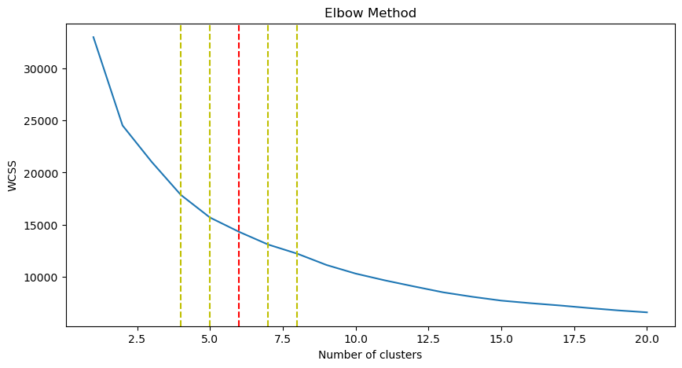

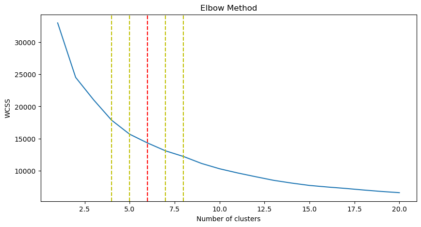

```
[33026.00000000002, 24531.23551452144, 21029.320562640984, 17854.49849237767, 15675.670215686172, 14299.336458017322, 13074.840573340696, 12194.738765161841, 11111.77424220181, 10284.745395496218, 9635.083288567035, 9049.786250451969, 8484.394250133431, 8055.634219552009, 7683.889602981953, 7438.507…
```

```python
# Performing KMeans clustering with upto 20 clusters and plotting the elbow plot with wcss
# use the following for your kmeans parameters: init='k-means++', max_iter=300, n_init=10, random_state=0

wcss = []
for i in range(1, 21):
    # your code here
    #raise NotImplementedError
    kmeans = KMeans(n_clusters=i, max_iter=300, init='k-means++', n_init=10, random_state=0)
    kmeans.fit(X)
    wcss.append(kmeans.inertia_)

# Plotting the elbow plot
plt.figure(figsize=(10, 5))
plt.plot(range(1, 21), wcss)

# Add dashed line at 5,6,7,8 clusters
plt.axvline(x=4, color='y', linestyle='--')
plt.axvline(x=5, color='y', linestyle='--')
plt.axvline(x=6, color='r', linestyle='--')
plt.axvline(x=7, color='y', linestyle='--')
plt.axvline(x=8, color='y', linestyle='--')
plt.title('Elbow Method')
plt.xlabel('Number of clusters')
plt.ylabel('WCSS')
plt.show()

print(wcss)
```

```python
# your code here
#raise NotImplementedError
```

Now, complete the code below to perform KMeans clustering with upto 20 clusters and calculate the silhouette score. If your code is correct, you should generate a plot similar to the following:

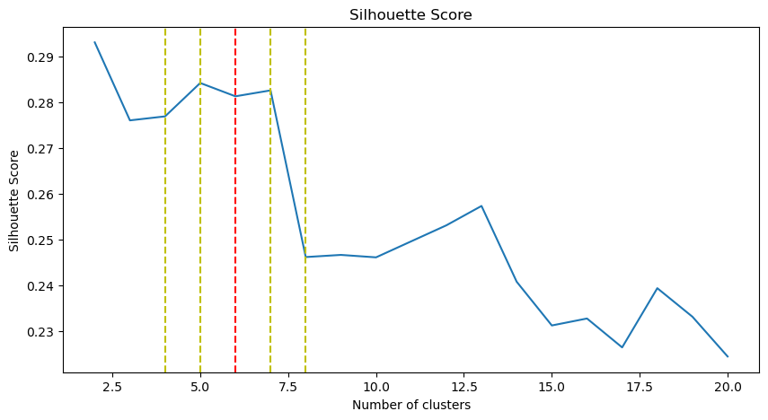

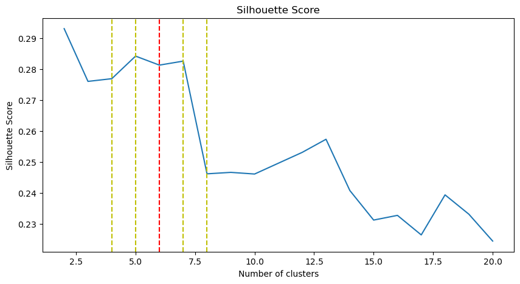

```
[0.2931538688624098, 0.2761196162298992, 0.2769922657152058, 0.2842851895274518, 0.2813762736440965, 0.2826664593094992, 0.24626215413615293, 0.24673034386885448, 0.24619679306081255, 0.24969617157169907, 0.25319112360232743, 0.25742370149466903, 0.2408719794092439, 0.23131904770569273, 0.2328389748…
```

```python
# Performing KMeans clustering with upto 20 clusters and plotting the silhouette score
# use the following for your kmeans parameters: init='k-means++', max_iter=300, n_init=10, random_state=0

silhouette_score_list = []
for i in range(2, 21):
    # your code here
    #raise NotImplementedError
    kmeans = KMeans(n_clusters=i, max_iter=300, init='k-means++', n_init=10, random_state=0)
    cluster_labels = kmeans.fit_predict(X)
    silhouette_avg = silhouette_score(X, cluster_labels)
    silhouette_score_list.append(silhouette_avg)

# Plotting the silhouette score
plt.figure(figsize=(10, 5))
plt.plot(range(2, 21), silhouette_score_list)

# Add dashed line at 5,6,7,8 clusters
plt.axvline(x=4, color='y', linestyle='--')
plt.axvline(x=5, color='y', linestyle='--')
plt.axvline(x=6, color='r', linestyle='--')
plt.axvline(x=7, color='y', linestyle='--')
plt.axvline(x=8, color='y', linestyle='--')
plt.title('Silhouette Score')
plt.xlabel('Number of clusters')
plt.ylabel('Silhouette Score')
plt.show()

print(silhouette_score_list)
```

Next, we'll create parallel plots to visualize the clusters centroids.

```python
# creating parallel plots to visualize the clusters centroids

kmeans = KMeans(n_clusters=6, init='k-means++', max_iter=300, n_init=10, random_state=0)
kmeans.fit(X)

# Adding cluster labels to the dataframe
df_centroids = pd.DataFrame(kmeans.cluster_centers_) #, columns=features)
df_centroids['cluster'] = df_centroids.index

fig = px.parallel_coordinates(df_centroids, color='cluster', color_continuous_scale=px.colors.sequential.Viridis)
fig.show()
```

[interactive chart not shown]

```python
# creating parallel plots to visualize the clusters centroids

kmeans = KMeans(n_clusters=6, init='k-means++', max_iter=300, n_init=10, random_state=0)
kmeans.fit(X)

# Adding cluster labels to the dataframe
df_centroids = pd.DataFrame(kmeans.cluster_centers_, columns=features)
df_centroids['cluster'] = df_centroids.index

fig = px.parallel_coordinates(df_centroids, color='cluster', color_continuous_scale=px.colors.sequential.Viridis)
fig.show()
```

[output not shown]

Finally, we'll perform heirarchical clustering.

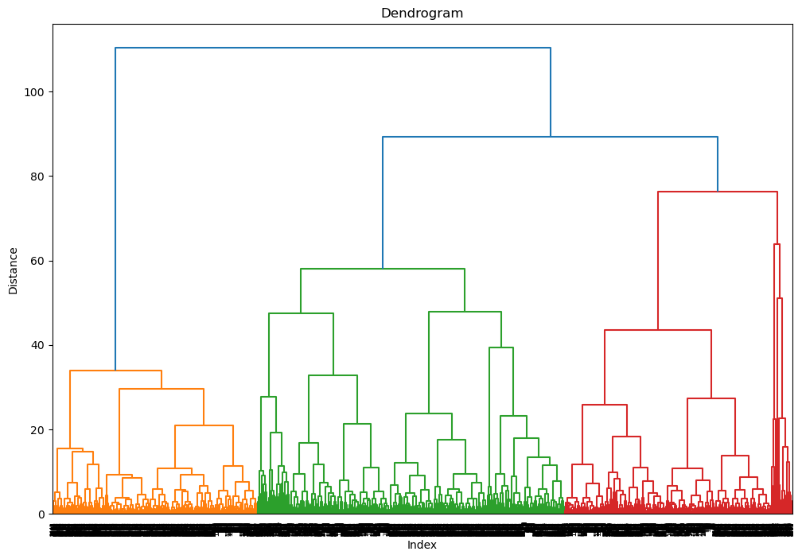

```python
# Performing Heirarchical clustering and plotting the dendrogram

Z = linkage(X, 'ward')

plt.figure(figsize=(12, 8))
dendrogram(Z)
plt.title('Dendrogram')
plt.xlabel('Index')
plt.ylabel('Distance')
plt.show()
```